# BIOST 561: using the command-line and the server

Lecture 7

# Announcements

# Note 1 about HW3: Using `expect_true()`

- I personally only use `expect_true()` when I write tests
- (There’s nothing wrong with the other `testthat` functions, I’m just not used to using them and I forget what they are)
- `expect_true()` is expecting (in a literal sense) only **one** `TRUE`

```r
set.seed(0)
vec1 <- stats::rpois(5, lambda = 1)
set.seed(0)
vec2 <- stats::rpois(5, lambda = 1)
set.seed(1)
vec3 <- stats::rpois(5, lambda = 1)

vec1
```

```
## [1] 2 0 1 1 2
```

```r
vec2
```

```
## [1] 2 0 1 1 2
```

```r
vec3
```

```
## [1] 0 1 1 2 0
```

```r
testthat::expect_true(vec1 == vec2)
```

```
## Error:
## ! Expected `vec1 == vec2` to be TRUE.
## Differences:
## `actual`:   TRUE TRUE TRUE TRUE TRUE
## `expected`: TRUE
```

- Uh oh! It’s not happy. In these cases, we want to use `all()` (or, when you want to show two things aren’t the same, `any()`)

```r
testthat::expect_true(all(vec1 == vec2))
testthat::expect_true(any(vec1 != vec3))
```

# Note 2 about HW3: `Imports:` vs. `Suggests:`

- Some of you had questions regarding `Imports:` versus `Suggests:` in your `DESCRIPTION` file
- You can look at https://r-pkgs.org/dependencies-mindset-background.html#sec-dependencies-imports-vs-suggests
- Short answer: The difference is how strictly you (the developer of the package) require the users to have other R packages installed to use your package
  - `Imports:` will ensure the user has all these packages installed when they load your package
  - `Suggests:` is “it’ll be nice if a user has these packages installed, in which case, they’ll load them. But if the user doesn’t have these packages installed, my package can still be loaded.”

# Note 3 about HW3: An annoying `utils` warning

Many of you had a warning when you ran `devtools::check()` that reads something like this:

```
Undefined global function or variables:
  combn
Consider adding
  importFrom("utils", "combn")
```

To fix this:

- In your `.R` function, instead of using `combn(clique_nodes, 2)` (or something like that), write `utils::combn(clique_nodes, 2)`. This **declares** that you’re using the `combn()` function from the `utils` package.
- Make sure `utils` is under `Imports:` (or `Suggests:`) in your `DESCRIPTION` file.

# Note 4 about HW3: What did I mean “no correct solution”?

- Many tasks involving cliques for graphs are **notoriously** hard.
- Consider the task of answering a “yes/no” question – does a given graph have a clique of size `k` or larger (for some value of `k`)?
  - This is question is what computer scientists calls “NP-complete”
  - We are **not** going to get into this since it’s way beyond this course, but essentially this means: there is no good way to solve this problem aside from a brute-force search

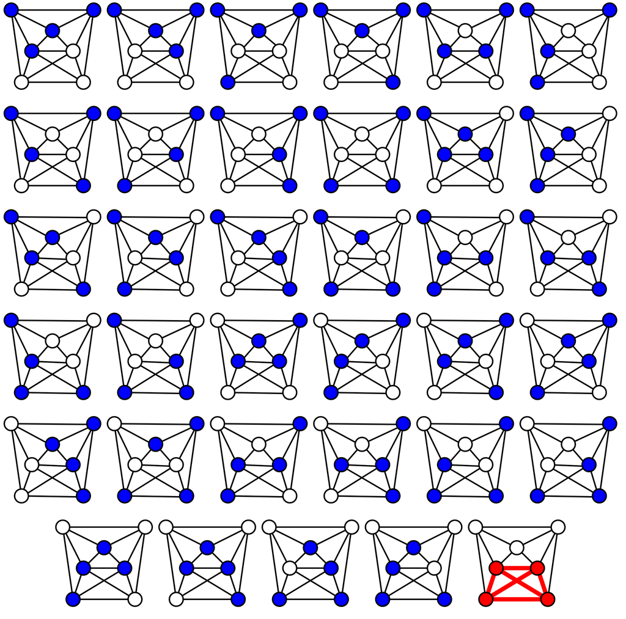

- If your graph has 30 nodes, this means you’re roughly checking `2^30=1073741824` graphs to find if there’s a clique of size `k` or larger.
- See https://en.wikipedia.org/wiki/Clique_problem and https://www.youtube.com/watch?v=pQsdygaYcE4

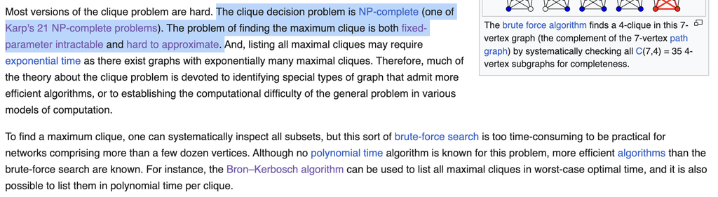

- You’re coding a function to find the maximal partial clique (which is different from the famous “clique decision” problem and also different from the “maximal clique” problem), but take my word, it’s still just as impossibly hard (although I do not have a proof of this)
- If you’re fascinated by “how we classify how difficult a computational problem is”, then you probably would enjoy a CS theory class.

# Debugging

- The reason I didn’t say too much about debugging until now is because there aren’t very many general principles/tools to help debugging.
- Debugging is very person-specific and code-specific
- Nonetheless, I can provide a few guiding principles on how to conceptualize debugging
- There’s two types of “bugs”:
  - 1. Your code crashed (i.e., did not complete) or unexpectedly returned a bunch of `NA`s or `NaN`s.
  - 2. Your code gave an output that looks reasonable but it failed your unit tests.

# Two important principles on debugging: Reproducing errors

One: Find how to **reproduce** your errors

- That is, you want to design a minimal example that yields the same “bug” consistently
- You can’t fix a problem if you don’t know what exactly the problem is
- This is simpler said than done, especially as you start designing more and more complicated functions
- If your function relies on random number generation, be sure to use the `set.seed()` function.
- This is why it’s important to:
  - 1. Refactor your code by packaging many lines of code into small/simple functions (i.e., “children” functions).
  - 2. Testing the small/simple functions first, and work your way “up” to the main function (i.e., “parent” functions)
  - Both aspects together help making minimal examples easier

# Two important principles on debugging: Tracing

Two: **Tracing** your code to find the specific line that fails

- This is “detective work”.
- Your code crashing or your unit test failing is “the murder at the crime scene.” Then, you need to use your thinking and understanding of code to gather “evidence” that points to the “culprit”.
- Just like a true crime, the specific function that caused the code to crash might not be the actual culprit. The real murder could’ve been done a long time before your code crashed.

```r
median_random_rowSums <- function(mat,
                                  trials = 1000){
  p <- ncol(mat)
  rowsum_vec <- sapply(1:trials, function(trial){
    bool_vec <- stats::rbinom(p, size = 1, prob = 0.5)
    idx <- which(bool_vec == 1)
    mat_tmp <- mat[,idx]
    return(rowSums(mat_tmp))
  })

  stats::median(rowsum_vec)
}

mat <- matrix(1:25, nrow = 5, ncol = 5)
median_random_rowSums(mat)
```

```
## Error in `rowSums()`:
## ! 'x' must be an array of at least two dimensions
```

- In this example, even though the “body at the crime scene” is the `rowSums(mat_tmp)` function, the real murder was done in `mat_tmp <- mat[,idx]`. If `idx` were just a vector of length one, `mat_tmp` would actually be a vector (and not a matrix), which does not work with the `rowSums()` function.

# Two ways to do tracing

**Non-interactive:**

- You add `print()` statements in strategic places in your code to figure out the status of your code at different times.
- This helps you figure out: 1) where the code crashed, and 2) what the status of the code is before the code crashed
- Typically, this strategy is better for when you’re trying to figure out why your code crashed (rather than why your code doesn’t pass your unit test despite not crashing).

```r
median_random_rowSums <- function(mat,
                                  trials = 1000){
  p <- ncol(mat)
  rowsum_vec <- sapply(1:trials, function(trial){
    print(paste0("Trial: ", trial))
    bool_vec <- stats::rbinom(p, size = 1, prob = 0.5)
    idx <- which(bool_vec == 1)
    print(idx)
    mat_tmp <- mat[,idx]
    vec <- rowSums(mat_tmp)
    print(vec)
    return(vec)
  })

  stats::median(rowsum_vec)
}

set.seed(0) # to reproduce my errors!
mat <- matrix(1:25, nrow = 5, ncol = 5)
median_random_rowSums(mat)
```

```
## [1] "Trial: 1"
## [1] 1 4 5
## [1] 38 41 44 47 50
## [1] "Trial: 2"
## [1] 2 3 4 5
## [1] 54 58 62 66 70
## [1] "Trial: 3"
## [1] 4
```

```
## Error in `rowSums()`:
## ! 'x' must be an array of at least two dimensions
```

**Interactive:**

- You can use the `browser()` function or set breakpoints in RStudio.
- You can see https://adv-r.hadley.nz/debugging.html for more details
- I personally don’t use this as often since it’s a bit clunky. However, it **is** very useful when you’re debugging code that didn’t crash but still gave the wrong answer. This is because you can interactively write code to check all the variables inside a function.
- (We’ll do some demos of this with any remaining time at the end of class)

# NOTE ABOUT OPERATING SYSTEMS FOR THIS LECTURE

- The procedures for Windows laptops will be **slightly/dramatically** different compared to Mac laptops
- I (Kevin) only have a Mac, so I might not be as immediately familiar with how adjust the procedures for Windows
  - I will write (in these slides) my best educated-guess on what the procedure for Windows is

# Opening the terminal (Macs)

- You have `Terminal` program on your Mac

[figure not shown]

- It’ll look like something like this. (Your screen might not look exactly the same, depending on the style of your `Terminal`)

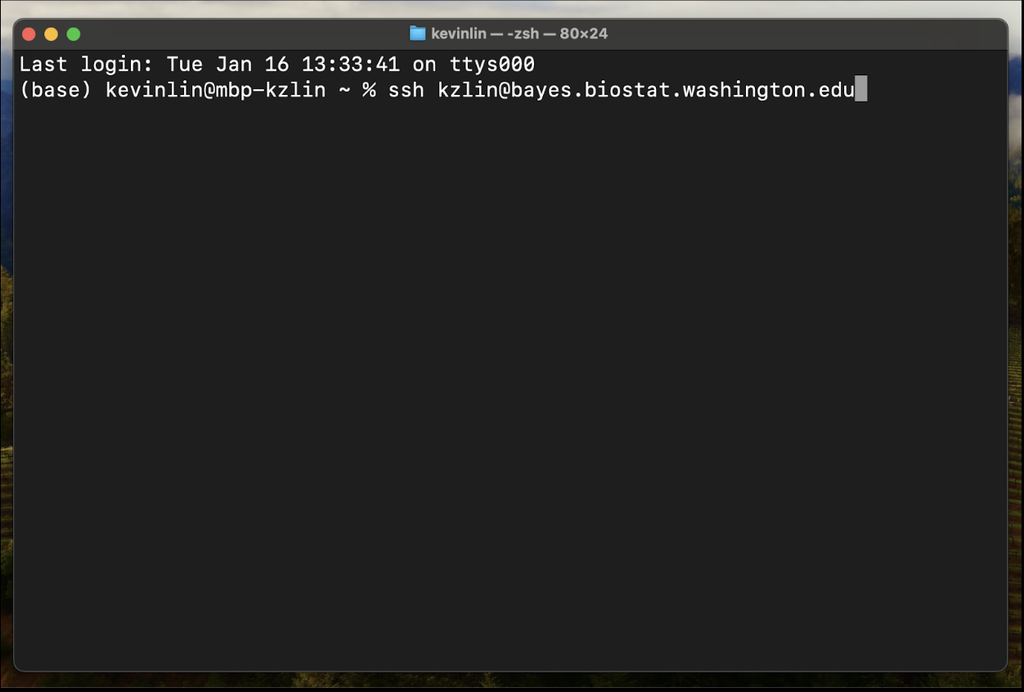

# Opening the terminal (Windows)

- You might already have `Windows PowerShell` on your laptop already, which is all you need.

Alternative 1:

- The `Command Prompt` is not the same thing as the `BASH`. See https://attuneops.io/difference-between-cmd-vs-powershell-vs-bash/
- However, if you’re only using the `Command Prompt` to `ssh` into Bayes, once you’ve `ssh`-ed into Bayes, your `Command Prompt` will behave like a Linux terminal.

Alternative 2:

- You want to install “Git for Windows” at https://gitforwindows.org/, and use the `Git BASH` application
- For more information, you can follow https://www.youtube.com/watch?v=4xqVv2lTo40 and https://www.youtube.com/watch?v=AdzKzlp66sQ

# Navigating around the terminal

- See https://docs.google.com/document/d/1369bf2WE7n2FzhFoqUv2rgWMZRurYfjHmGMUNHfOWBU/edit?usp=sharing
- A list of useful commands
  - `cd`: Change directory
  - `ls`: List the files inside a folder
  - `mv`: Move a file/folder
  - `cp`: Copy a file/folder

# Using Git from the terminal

- A list of commands for git
  - `git status`: Look at the status of your GitHub repository (what are files that have changed, has it been staged, etc.)
  - `git add`: Add (i.e., “stage”) a file to be committed
  - `git commit`: Commit all the staged files
  - `git push`: Push your repository from your current location onto GitHub.com
  - `git pull`: Pull your repository from GitHub.com to your current location
- We will do an in-class demo of this now

# Moving on: Interacting with the Biostat server

- For large datasets or a lot of computing, it’s somewhat unrealistic to do all the computation on your local laptop
- Why?
  - Your laptop might be “faster” than a typical computer (in terms of new CPU/GPU), but it probably doesn’t have as much memory or storage as a server
  - Once you “close” your laptop, all your jobs are killed. That means if you run a job that takes 12 hours, you have to literally not close or put your laptop to sleep for 12 hours.
  - Your collaborators can’t see the results (since we don’t put large datasets on GitHub, but your collaborator also can’t access the files on your laptop)

# Logging into the server

- Make sure you’ve installed Husky OnNet. See the overview I wrote here: https://docs.google.com/document/d/1FGdD3O7nL-xQfPRefHb9fxmqf43HYHGLgD-V4UZC6ec/edit?usp=sharing.

It should look something like this:

[figure not shown]

- Using the `Terminal` (for Macs) or `Windows PowerShell` (for Windows):

[figure not shown]

- You want to type in: `ssh [username]@bayes.biostat.washington.edu`

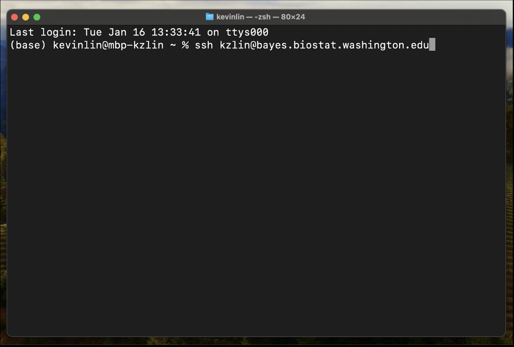

- You’ll be asked for the password. After successfully typing in your password, you’ll arrive at the landing page for the server. Congratulations!

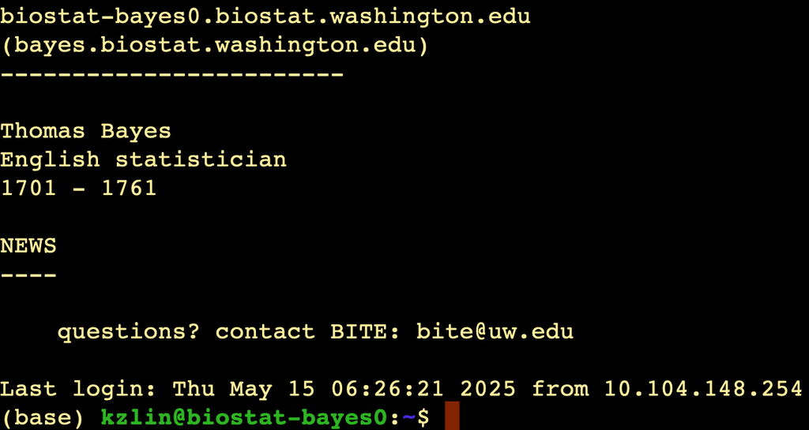

# Moving files to/from the server

Two ways:

- Via GitHub – great for code and figures
- Via `scp` in the Terminal (for Macs) or in `Windows PowerShell` (or `Command Prompt` or `MobaXterm`) (for Windows) – great for data and results
- For **our** course, we will primarily use GitHub to transfer files to/from your laptop to Bayes.
  - Technically, this isn’t ideal for data and results because GitHub doesn’t like files above 50 Mb
  - However, we will do this for the course since 1) nothing you generate in this course should be a large file, and 2) it will make your life easier since there’s a lot of new things you’re already learning
  - In a literal sense though, I would tell you about `scp` (hopefully) sometime later in the course

# In-class preparation (Part 1):

- [[I’ll be doing this live. We’ll spend 5-10 minutes to let you follow along on your laptop.]]
- I put two files on Canvas. Please download them to your local laptop and put them into your `UWBiost561` R package under the `vignettes` folder
- Try this (if you can get it to work):
  - On your laptop: Open up `Terminal` (on Mac) or `Windows PowerShell` (on Windows)
  - Navigate to your `UWBiost561` R package via the `cd` command
  - Type in `git status` into the command line. This **should** show your Git repository’s status, and it should also show the 2 new files you’ve just added
  - Type in `git add *` into the command line. This is a “lazy way” to simply add/“stage” all your files for the commit. (This is functionally equivalent to clicking the check-box when you had added files via R Studio)
  - Type in `git commit -m "Pushing code for server"` into the command line. (In general, the things in `"..."` is your commit message.)
  - Type in `git push origin main`. It will ask you for your username **and** your GitHub PAT (this is the super-secret password you had made in HW1. It’s the one that starts with `ghp_`…)
- Or (if you couldn’t get the command-line to work)
  - You can add & commit & push code to your GitHub via R Studio, as you’ve already been doing for the HWs
- Now, in your Internet Browser, double check you can see your files on GitHub.com
- Now, log into Bayes
  - This will also involve using the `Terminal` or `Windows PowerShell` (see a few slides ago)

# In-class preparation (Part 2):

- So far so good! Now we’re going to pull your GitHub into your Bayes. (This is where you’ll probably get lost. Remember, you’re **not** looking at the files on your own personal laptop. You’re now on the departmental server.)
- We’re going to do the simplest thing (which is **not** what I usually recommend, which involves more steps). I will tell you what I actually recommend in a future lecture
  - On the internet browser, find your GitHub repository’s URL. (For example, this might be: `https://github.com/UW561/UWBiost561`)
  - Back in `Terminal` or `Windows PowerShell`, type `cd ~`. (This makes sure you are in your home directory.)
  - Then, type in `git clone https://github.com/UW561/UWBiost561` (or whatever your GitHub is – this will require you to enter your GitHub username and your GitHub PAT)
  - **Note**: If you have already cloned the repository in a previous session, `git clone` will fail because the folder already exists. In that case, run `cd UWBiost561 && git pull` to update it instead.
  - You should download your entire GitHub repository into your home directory on Bayes.

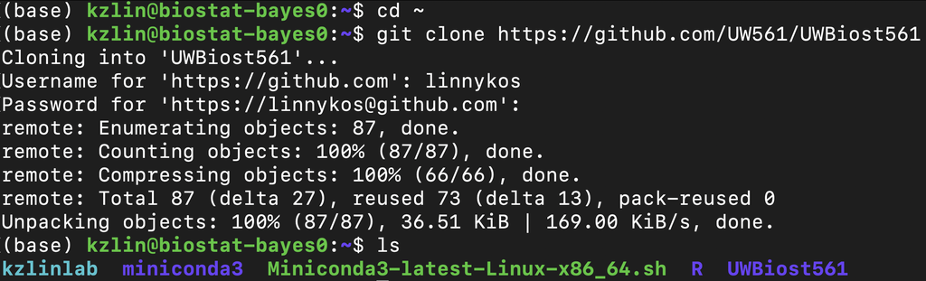

- You can look around! Type in `cd UWBiost561/` (you can tab-complete)
- To see all the files, you can type `ls`
- You can look in your vignettes folder, via `cd vignettes/` and then look at the contents of folder via `ls`

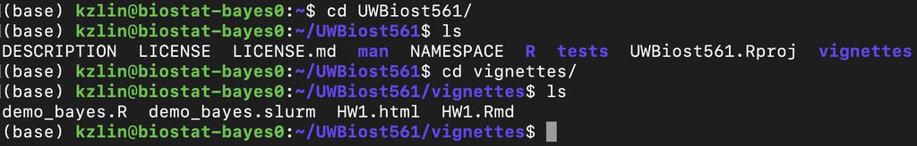

# Submitting a job on the server

Okay, so what exactly did you put into your `UWBiost561` package that’s now on Bayes as well?

There are multiple moving parts:

- The `.R` script: `demo_bayes.R` is a simple R script that computes the eigen-decomposition of a big, random matrix
- The `.slurm` script: `demo_bayes.slurm` is a shell script (i.e., code that interacts with an operating system directly) that tells Bayes **how** to run `demo_bayes.R`

# Looking at `demo_bayes.R` (nothing too special)

```r
# store some useful information
date_of_run <- Sys.time()
session_info <- devtools::session_info()
set.seed(10)

# generate a random matrix
p <- 2000
mat <- matrix(rnorm(p^2), p, p)
mat <- mat + t(mat)

# print out some elements of the matrix
print(mat[1:5,1:5])

# compute eigenvalues
res <- eigen(mat)

# save the results
save(mat, res,
     date_of_run, session_info,
     file = "~/demo_bayes_output.RData")

print("Done! :)")
```

# What on earth is a `.slurm` script?

- What the heck is SLURM anyway?
- SLURM is a job manager. (We will talk about server etiquette more next week.) It **manages** the computing resources for many many people

[figure not shown]

- You will run your job on the server “in the background”
  - This means even if your connection with the server breaks, your job will still be running. (This is a good thing! You don’t want to keep your laptop on for hours and hours.)
  - To do this, the server needs to allocate computing resources for your job
  - How much memory does the job need? How much time the job need?
  - Remember, the server is for all users on the system. The SLURM script helps the server determine how to best allocate resources (primarily time and computing power)

# What does a typical `.slurm` script look like?

```
#!/bin/bash

#SBATCH --job-name=demo
#SBATCH --account=biostat
#SBATCH --partition=students-12c128g

#SBATCH --time=12:00:00
#SBATCH --mem-per-cpu=10gb

R CMD BATCH --no-save --no-restore demo_bayes.R
```

- This is what a SLURM script looks like.
- It specifies a bunch of different things
- Realistically, you make a new SLURM script (via copy-paste of a previous one) and just change a few things. (I personally never memorized how to write a SLURM script from scratch)

# What does a typical `.slurm` script look like?

```
#!/bin/bash

#SBATCH --job-name=demo
#SBATCH --account=biostat
#SBATCH --partition=students-12c128g

#SBATCH --time=12:00:00
#SBATCH --mem-per-cpu=10gb

R CMD BATCH --no-save --no-restore demo_bayes.R
```

- Your SLURM script **must** must must always start with this line.
- (Don’t ask why. This is one of those things where you do without questioning it. If you must know, you can google “hashbang”)

# What does a typical `.slurm` script look like?

```
#!/bin/bash

#SBATCH --job-name=demo
#SBATCH --account=biostat
#SBATCH --partition=students-12c128g

#SBATCH --time=12:00:00
#SBATCH --mem-per-cpu=10gb

R CMD BATCH --no-save --no-restore demo_bayes.R
```

- This is the most important line in the SLURM script
- `R CMD BATCH` is the command-line function to run a `.R` file
- The flags `--no-save --no-restore` are optional. (It makes your life just a bit easier, so might as well keep them around.)
- The argument is `demo_bayes.R`, which is the `.R` file you wish to run
- That is, this file (`demo_bayes.slurm`) is telling Bayes: “Hey, I wish to run the script `demo_bayes.R`”

# What does a typical `.slurm` script look like?

```
#!/bin/bash

#SBATCH --job-name=demo
#SBATCH --account=biostat
#SBATCH --partition=students-12c128g

#SBATCH --time=12:00:00
#SBATCH --mem-per-cpu=10gb

R CMD BATCH --no-save --no-restore demo_bayes.R
```

- This is the name of your job
- The flag is `--job-name` and the value I’m setting it to is `demo`
- (More on this later)

# What does a typical `.slurm` script look like?

```
#!/bin/bash

#SBATCH --job-name=demo
#SBATCH --account=biostat
#SBATCH --partition=students-12c128g

#SBATCH --time=12:00:00
#SBATCH --mem-per-cpu=10gb

R CMD BATCH --no-save --no-restore demo_bayes.R
```

- This is the account you’re using to run your job
- The flag is `--account` and the value I’m setting it to is `biostat`
- You will **never** change this when you’re using Bayes (since you’re a Biostat student running your job on the Biostat server), so don’t worry about this. Just keep it here and never touch it

# What does a typical `.slurm` script look like?

```
#!/bin/bash

#SBATCH --job-name=demo
#SBATCH --account=biostat
#SBATCH --partition=students-12c128g

#SBATCH --time=12:00:00
#SBATCH --mem-per-cpu=10gb

R CMD BATCH --no-save --no-restore demo_bayes.R
```

- This is the partition your running your job on
- The flag is `--partition` and the value I’m setting it to is `students-12c128g`
- This is student partition on Bayes. Only students (you guys) can use it. I (Kevin) cannot use it.
- (More on this later – you can change to another partition if you think the current partition you’re using is too busy)

# What does a typical `.slurm` script look like?

```
#!/bin/bash

#SBATCH --job-name=demo
#SBATCH --account=biostat
#SBATCH --partition=students-12c128g

#SBATCH --time=12:00:00
#SBATCH --mem-per-cpu=10gb

R CMD BATCH --no-save --no-restore demo_bayes.R
```

- After the `R CMD BATCH` line, this is the next most important line in the entire SLURM script
- The flags are `--time` and `--mem-per-cpu`, and the values I’m setting them to are `12:00:00` and `10gb`
- This tells Bayes: “Hey Bayes, I think my job will need **at most** 12 hours in time and **at most** 10 Gigabytes of memory
- This helps Bayes figure out how to allocate resources for your job
- (More on this next week, when we talk about server etiquette. Remember, Bayes is for the **entire department**, not just you!)

# In-class, running your first SLURM script on the server

- [[I’ll be doing this live. We’ll spend 5-10 minutes to let you follow along on your laptop.]]
- Navigate to be inside your `vignettes/` on Bayes (using `cd`)
- Make sure you’re in the right place using `ls`. You should see `demo_bayes.R` and `demo_bayes.slurm` (along all your other HW vignettes)
- In the command line, type in `sbatch demo_bayes.slurm`. You should see `Submitted batch job ...`
- This script only takes a minute or two to run. While it’s still running, type in `squeue --me`. This will show you which jobs you are running and their status

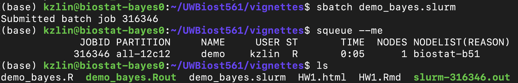

- After a minute or two, your job will finish. You’ll notice a bunch of new files. For example, in your current `vignettes/` directory, you’ll see `demo_bayes.Rout` (and a `slurm-[job ID].out` – we usually don’t need to look at latter file).
- You can type `cat demo_bayes.Rout` into the command line to see what the contents of this file is. It’s a text file, and it literally prints out everything that happened in the R session that you ran in the background

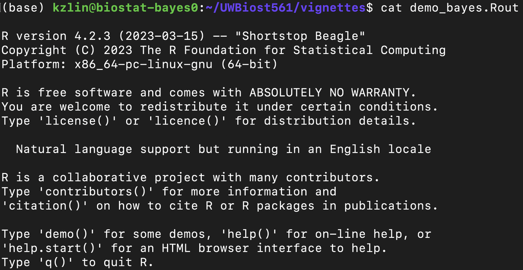

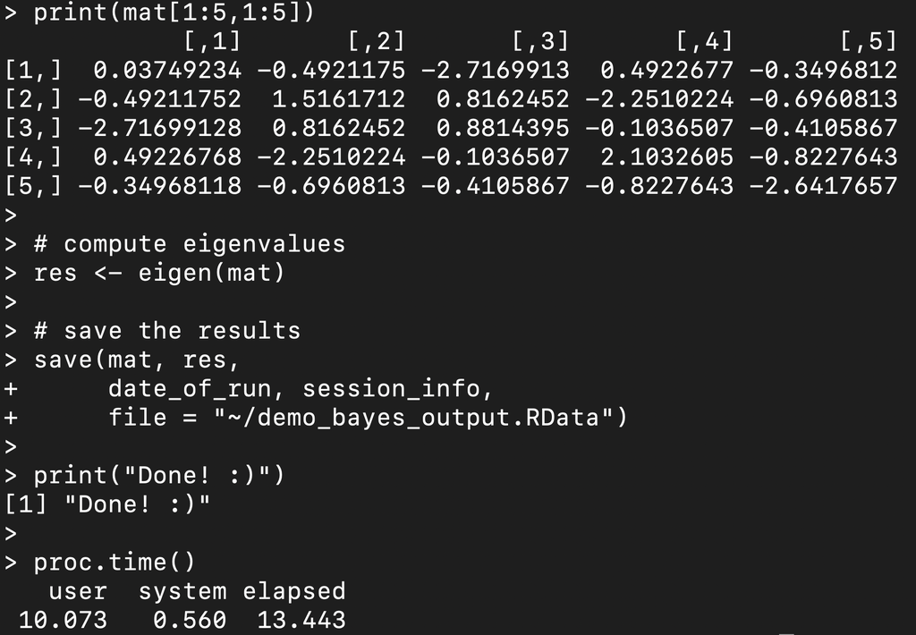

- What about the output? Recall we actually saved it outside the GitHub repository in `demo_bayes.R` via `save(..., file = "~/demo_bayes_output.RData")`. It’s under our home directory. Navigate to it via `cd ~`.

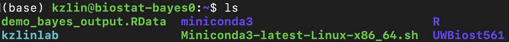

- How do you see the results (in `demo_bayes_output.RData`)? Bayes is a server that has R, so you can just open up R! Type in `R`.

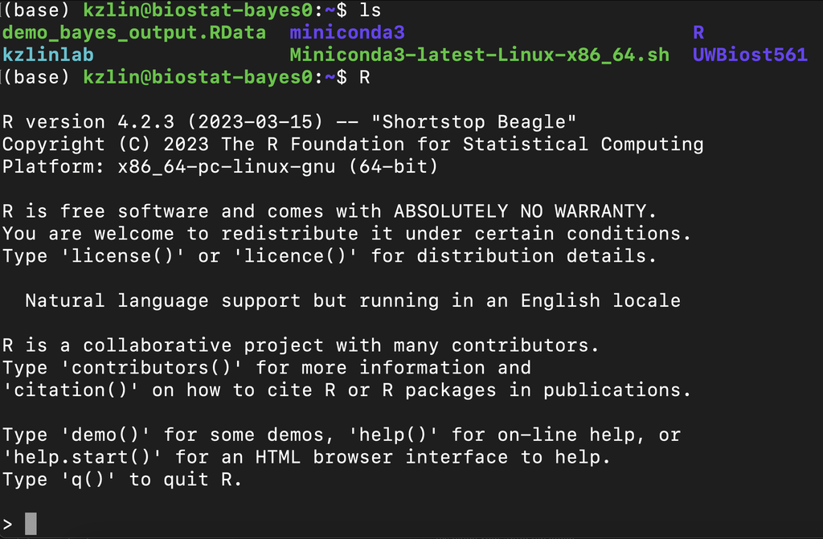

- Then, you can interact with this just like any other R session. The only difference is that (compared to R Studio), you **only** have the R console. You don’t have any other panels or drop-down menus. So you’ll need to learn all the R commands to navigate around (which is why I’ve been typically telling you the specific R commands to do things, instead of which buttons to click on in R Studio)

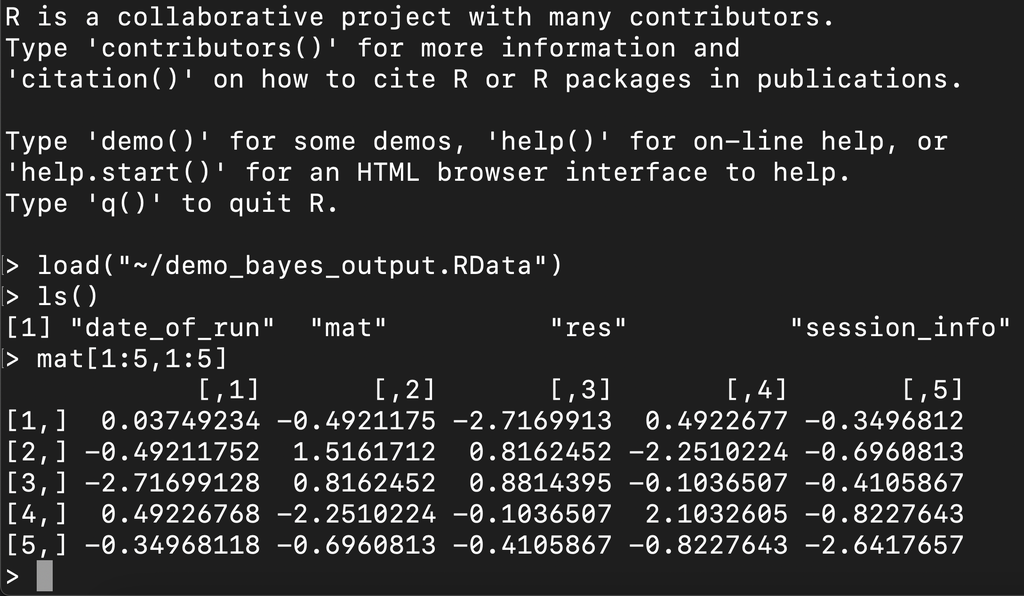

# Hm… about that interactive R session

Question: Why didn’t we just run our `demo_bayes.R` script in this interactive R session (albeit not having a fancy GUI like R Studio)?

Answer: If you run a script interactively and your SSH connection drops (or you close your laptop), the R session is **immediately killed** and your computation is lost. SLURM jobs run in the background, completely decoupled from your connection, so they keep running even if you disconnect or your laptop dies. **More on this next week** when we talk about server etiquette in more depth.

# A few notes about `.slurm` scripts

- The file suffix of a SLURM script (for example, `demo_bayes.slurm`) does **not** technically need to be `.slurm`. It also did **not** technically need to be called `demo_bayes`.
  - **HOWEVER**: I would **strongly** recommend you to follow this practice. This helps you remember: 1) certain files are SLURM scripts, and 2) which `.slurm` files are associated with which `.R` files

# Some practical advice about editting code (that might contradict my actual advice outside this course)

- I would recommend you to **not** edit your `UWBiost561` R package on the server
  - (This would require me to tell you about `vim`. But more importantly, it’s very easy to have conflicting versions of `UWBiost561` package if you simultaneously changes on your local laptop and on Bayes)
- Instead, I would suggest you (for this course) to:
  - 1. Modify your code in R Studio on your laptop
  - 2. Commit your changes to your Git repository and push them onto GitHub
  - 3. On the Bayes server, pull your new changes into your `UWBiost561` repository
  - (Hence, technically speaking, this is a one-way edit. You only ever modify your code on your local laptop. While in general, you don’t need to abide by this practice, it **will** make your life easier if you feel overwhelmed by the command line and the server.)

# Graphical explanation

[figure not shown]

# Graphical explanation

[figure not shown]

# Graphical explanation

[figure not shown]

# What’s to come in HW4

- As I’ve stated, with the completion of HW3, you all have a working implementation of `compute_maximal_partial_clique()`
- I will be compiling all your versions (anonymized) into a couple files that I will be upload to Canvas for you to download and put into your `R` folder in your `UWBiost561` package
- You will be constructing a simulation study comparing all the different implementations on Bayes
- HW4 will not technically be harder than HW3, but it will probably feel overwhelming mainly because there’ll be more moving components

# With the remaining time…

- More demos using the server or using Git in the command line
- We will get more practice with the server next time!
- Importantly, we will talk about:
  - Server “etiquette” (since it’s a shared resource among all department members)
  - Effectively manage jobs/files
  - Make simulation studies
  - Git pulls (and merges and branches)
- Looking ahead:
  - Lecture 8 will be about the above topics
  - Lecture 9 will be about Pkgdown and Github.io (your personal websites)
  - Lecture 10 (last class) is a catch-all. We will discuss a bit about your simulation results in HW4, a bit about Python, and a bit about ChatGPT

# Additional links

- Companion Google Docs for Linux commands and using Bayes
  - https://docs.google.com/document/d/1369bf2WE7n2FzhFoqUv2rgWMZRurYfjHmGMUNHfOWBU/edit?usp=sharing
  - I’ll be adding more content to this, even after I post HW4
- Debugging
  - https://adv-r.hadley.nz/debugging.html
- Cheatsheet for Git commands
  - https://education.github.com/git-cheat-sheet-education.pdf
- Cheatsheet for Linux commands
  - https://phoenixnap.com/kb/wp-content/uploads/2023/11/linux-commands-cheat-sheet-pdf.pdf
  - The most useful commands are the ones under “Directory Navigation” and Files”
- Cheatsheet for SLURM commands
  - https://www.carc.usc.edu/user-information/user-guides/hpc-basics/slurm-cheatsheet